# 6 Analyze your data

### 6.2.3 Calculate absolute change in pH

Another helpful metric is the change in pH from unspoiled milk to the pH after 8 days.

**Give it a try**

Annotate the code below to indicate what each line is doing.

```r
# Calculate the mean pH difference between milk age 0 and milk age 8
change_ph <- mean_ph |>
  filter(age %in% c(0, 8)) |>
  pivot_wider(names_from = age, values_from = mean_ph, names_prefix = "age_") |>
  mutate(ph_difference = age_0 - age_8)

# take a look at the summary table
change_ph |>
  kable(digits = 2)
```

| milk_type | age_0 | age_8 | ph_difference |
| --- | --- | --- | --- |
| buttermilk | 4.36 | 4.31 | 0.04 |
| chocolate | 6.37 | 4.82 | 1.55 |
| oat | 7.48 | 6.92 | 0.56 |
| whole | 6.60 | 4.61 | 1.99 |

**Give it a try**

Use your (gg)plotting skills to

1. Modify the color scheme to the colors you have picked (note that we are using fill not color).
2. Add your own custom axis titles.
3. Change it to the same theme you picked for your scatter plot.
4. Move the legend to the same place as in your other figure.

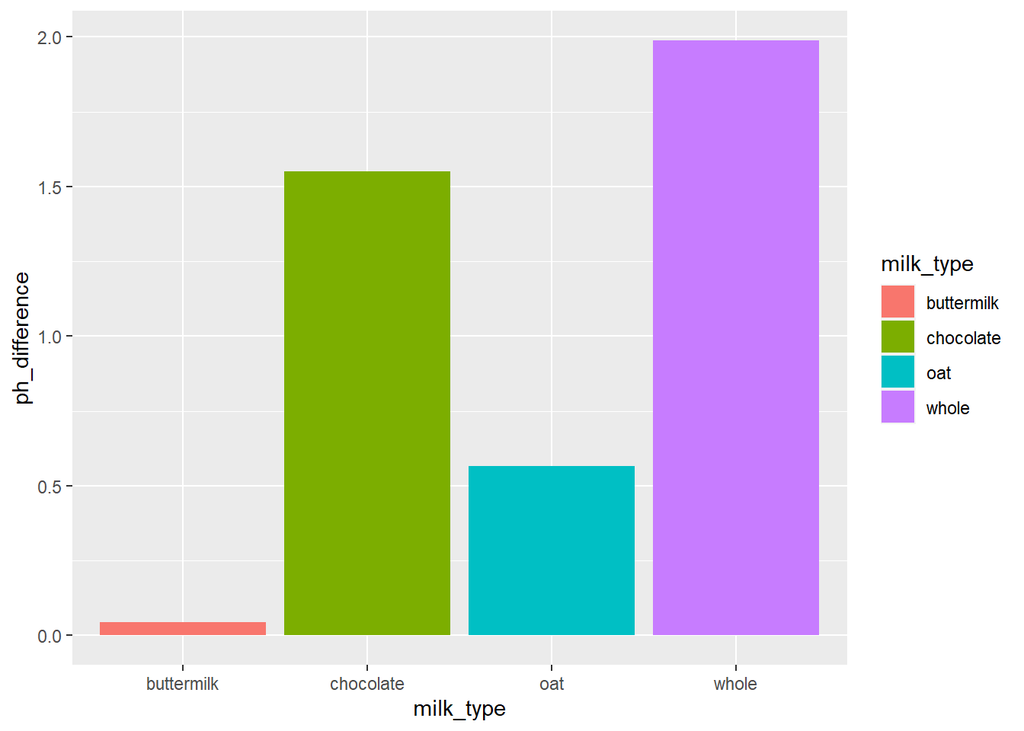

```r
ggplot(change_ph,
       aes(x = milk_type, y = ph_difference,
           fill = milk_type)) +
  geom_bar(stat = "identity")
```

.

**Answer**

This is where we notice some of the convenience of using code. Instead of having to rewrite everything you can just cut and paste the last for lines of the code from your scatter plot that specify color, labels and the theme.

You do have to change `scale_color_manual()` to `scale_fill_manual()` and of course change the axis titles to fit your plot.

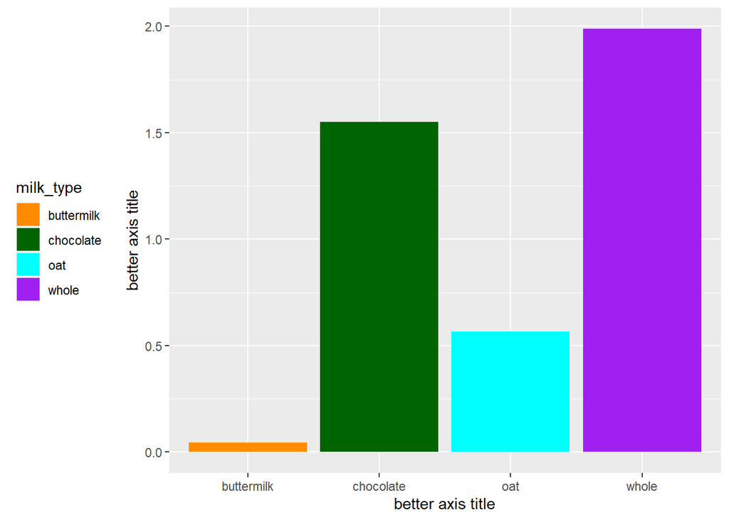

```r
ggplot(change_ph,
       aes(x = milk_type, y = ph_difference,
           fill = milk_type)) +
  geom_bar(stat = "identity") +
  scale_fill_manual(values = col) +
  labs(x = "better axis title",
       y = "better axis title") +
  theme_grey() +
  theme(legend.position = "left")
```

### 6.2.4 Rate of change

Finally, we can calculate the rate of change between each time point for each milk type. The code below will output a new column called `rate_of_change` that shows how pH changes per unit time (age) for each `milk_type`. The first row for each milk type will have `NA` since there’s no previous value to compare but we can easily filter those from the final output.

Instead of having to calculate the difference in pH between each time point and then dividing it by the number of days in between those time points we can use the function `lag()` which tells `R` to use the previous value in the table.

```r
# Calculate rate of change
rate_ph <- mean_ph |>
  arrange(milk_type, age) |>
  group_by(milk_type) |>
  mutate(rate_of_change = (mean_ph - lag(mean_ph)) / (age - lag(age))) |>
  ungroup() |>
  filter(!is.na(rate_of_change))

# print summary table
rate_ph |>
  kable(digits = 4)
```

| milk_type | age | mean_ph | rate_of_change |
| --- | --- | --- | --- |
| buttermilk | 1 | 4.3525 | -0.0050 |
| buttermilk | 4 | 4.3300 | -0.0075 |
| buttermilk | 8 | 4.3125 | -0.0044 |
| chocolate | 1 | 6.4450 | 0.0775 |
| chocolate | 4 | 5.9150 | -0.1767 |
| chocolate | 8 | 4.8175 | -0.2744 |
| oat | 1 | 7.7250 | 0.2425 |
| oat | 4 | 7.4875 | -0.0792 |
| oat | 8 | 6.9175 | -0.1425 |
| whole | 1 | 6.7650 | 0.1675 |
| whole | 4 | 4.4600 | -0.7683 |
| whole | 8 | 4.6100 | 0.0375 |

## 6.3 Microbial Community

Similar to the results from our Benedict’s tests our raw observations of our microbial community was documented in your notes in your data collection table along with pictures of the plate as a whole and the slides.

### 6.3.1 Classify relative abundance

We can determine the presence of fungal colonies on the plates and the slides allow us to determine whether yeast is present as well as identifying the presence of bacteria by shape.

**Consider this**

Together with your lab partner, take another look at our background information of known patterns of microbial succession in dairy milk.

Take a few notes in terms of why microbial groups mentioned here match our cell types and bacterial shapes.

1. Refrigerated, unspoiled milk has a pH of ~6.5
2. *Streptococcus* (round-shaped cocci) and *Lactobacillus* (rod-shaped bacilli) bacteria naturally occur in milk and survive pasteurization
3. *Streptococcus* and *Lactobacillus* both ferment lactose sugar into lactic acid and acetic acid
4. *Streptococcus* bacteria thrive in milk with pH > 5.5
5. *Lactobacillus* bacteria grow in milk with pH > 4.5
6. Two common bacteria that always manage to get into milk from the environment, *Pseudomonas* and *Achromobacter* (both rod-shaped bacilli), digest butterfat and produce a putrid smell
7. An acidic environment causes casein to solidify, or curd
8. Yeasts and molds grow well in acidic environments

.

**Your Answer Here**

[Take some notes]

We did not determine density or abundance which would be quantitative data but we can still classify our microbial data to created a ranking of relative abundance.

In the shared google folder for your section, open the slidedeck with our plate and slide photos in the `data` folder. Additionally, you will find a spreadsheet in the `results` folder names `microbe-community`.

**Give it a try**

Together with your partner analyze the photos.

- create a copy of the spreadsheet and rename it `microbe-community_initials-initials` (include initials of both you and your lab partner).
- view the plate photos and classify the microbial growth as a whole - remember we did not streak the whole plate, so you and your partner should compare the groups and come up with a standard way to classify.
  1. **No growth**: No visible microbial colonies or growth observed on the plate.
  2. **Minimal growth**: Very few small colonies observed, covering less than 10% of the plate.
  3. **Moderate growth**: Some visible colonies scattered across the plate, covering approximately 10-50% of the plate.
  4. **Substantial growth**: Many colonies present, covering 50-75% of the plate.
  5. **Extensive growth**: A dense colony presence, covering more than 75% of the plate, with colonies merging or almost completely covering the surface.
- view the slide photos (remember you have two per treatment) and classify the presence of the three bacteria shapes and yeast as
  1. **Absent**: No visible bacteria or yeast cells observed in the field of view.
  2. **Few**: Only a few individual bacteria or yeast cells present, scattered sparsely throughout the slide.
  3. **Common**: Several bacteria or yeast cells observed, but not densely clustered; they occupy approximately 10-50% of the field of view.
  4. **Abundant**: Many bacteria or yeast cells present, covering more than 50% of the field of view with some clusters or groups.
  5. **Dominant**: The field of view is densely packed with bacteria or yeast cells, with little to no empty space visible.
- Finally, take a look at the plate photos to classify fungal growth as:
  1. **None**: No visible mold growth on the plate; the surface is clear and free from any fungal growth.
  2. **Trace**: Very small amounts of mold visible, appearing as isolated spots or patches, covering less than 10% of the plate.
  3. **Moderate**: Mold growth is noticeable and covers approximately 10-50% of the surface area of the plate, with a few patches or clusters.
  4. **Abundant**: Mold growth is widespread, covering more than 50% of the plate, with large patches or a thick spread.
  5. **Extensive**: Mold growth is fully covering the surface of the plate, with dense growth that may overlap or dominate the entire plate.

Once you and your lab partner have agreed on your classifications, you will need to export your spreadsheet as a comma-delimited file[^2] (`*.csv`).

<sup>2</sup> This means that for each row, the end of a column (“limit”) is indicated by a comma.

- Go to `File` .
- Select `Download` and pick `comma separated values (csv)` from the drop-down menu.
- This should open a `Save As` dialogue box because at the beginning of the semester we set our browser to ask us where to download files. By default it will suggest `microbe-community - Sheet1` as the file name (it will automatically add `.csv` as the file format). Change that to `microbe-community` and save it - make sure that you know where, you created an `lb104` folder at the beginning of the semester, that is a good location.
- Finally, you will need to upload it to your `posit cloud` workspace.

### 6.3.2 Create a heatplot

Let’s read in our data and print and overview table. By default, `R` will organize column content that is a `character` (strings) alphabetically. We have categories that have a distinct ranking. Therefore, we will need to convert those columns into `factors` which allows us to create a hierarchical set of levels.

```r
# levels microbial growth
levels_growth <- c("none", "minimal", "moderate", "substantial", "extensive")

# levels cells
levels_cells <- c("absent", "few", "moderate", "abundant", "dominant")

# levels fungi
levels_fungi <- c("none", "trace", "moderate", "abundant", "extensive")

# read data
microbes <- read_delim(here("data", "microbe-community.csv"),
                       delim = ",") |>
  clean_names() |>
  mutate(microbial_growth = ordered(microbial_growth, levels = levels_growth),
         cocci = ordered(cocci, levels = levels_cells),
         bacilli = ordered(bacilli, levels = levels_cells),
         spirilla = ordered(spirilla, levels = levels_cells),
         yeast = ordered(yeast, levels = levels_cells),
         mold = ordered(mold, levels_fungi),
         age = as.character(age))

# print overview
microbes |>
  kable()
```

| milk_type | age | microbial_growth | cocci | bacilli | spirilla | yeast | mold |
| --- | --- | --- | --- | --- | --- | --- | --- |
| whole | 0 | none | dominant | few | absent | absent | none |
| whole | 1 | minimal | dominant | moderate | absent | absent | none |
| whole | 4 | moderate | moderate | dominant | absent | few | none |
| whole | 8 | substantial | few | dominant | absent | abundant | moderate |
| chocolate | 0 | none | dominant | moderate | absent | absent | none |
| chocolate | 1 | minimal | dominant | few | absent | few | none |
| chocolate | 4 | moderate | dominant | few | few | abundant | none |
| chocolate | 8 | extensive | dominant | few | moderate | dominant | extensive |
| oat | 0 | none | few | absent | absent | absent | none |
| oat | 1 | minimal | few | absent | absent | absent | none |
| oat | 4 | moderate | few | few | absent | few | none |
| oat | 8 | moderate | few | moderate | absent | few | none |
| buttermilk | 0 | none | few | absent | absent | absent | none |
| buttermilk | 1 | minimal | few | absent | absent | few | none |
| buttermilk | 4 | moderate | few | moderate | absent | moderate | none |
| buttermilk | 8 | substantial | few | moderate | absent | moderate | none |

An table like this holds all your results but it is not easy to make comparisons or a helpful way to present your results to others. One way to visualize this type of data is to make a heatplot, where the color of the tile corresponds to the rank of the categorical variable.

Let’s start by making a heatplot that visualizes the change in overall microbial growth for all milk treatments. To do this we will use `select()` to subset our `dataframe` to just contain the milk type, age, and microbial growth and then use that to create our heatplot.

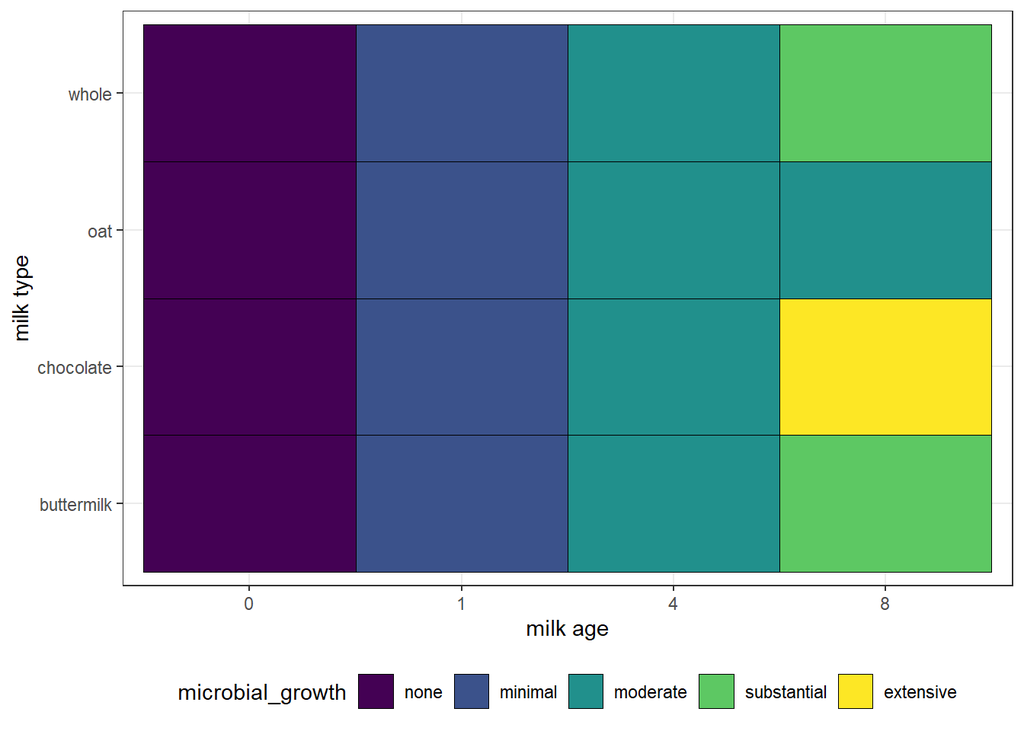

```r
# subset data
growth <- microbes |>
  select(milk_type, age, microbial_growth)

# create heatplot
ggplot(growth,
       aes(x = age, y = milk_type,
           fill = microbial_growth)) +
  geom_tile(color = "black") +
  scale_fill_viridis_d() +
  labs(x = "milk age", y = "milk type") +
  theme_bw() +
  theme(legend.position = "bottom")
```

.

**Give it a try**

Cut and paste the code above and then modify it to create a plot showing change in fungal growth for all milk types.

**Answer**

1. Let’s change the object name from `growth` to `mold`.
2. Instead of selecting the `microbial_growth` column we select the `mold` column
3. Then we just have to change the object name in the ggplot code and the fill to the `mold` column.

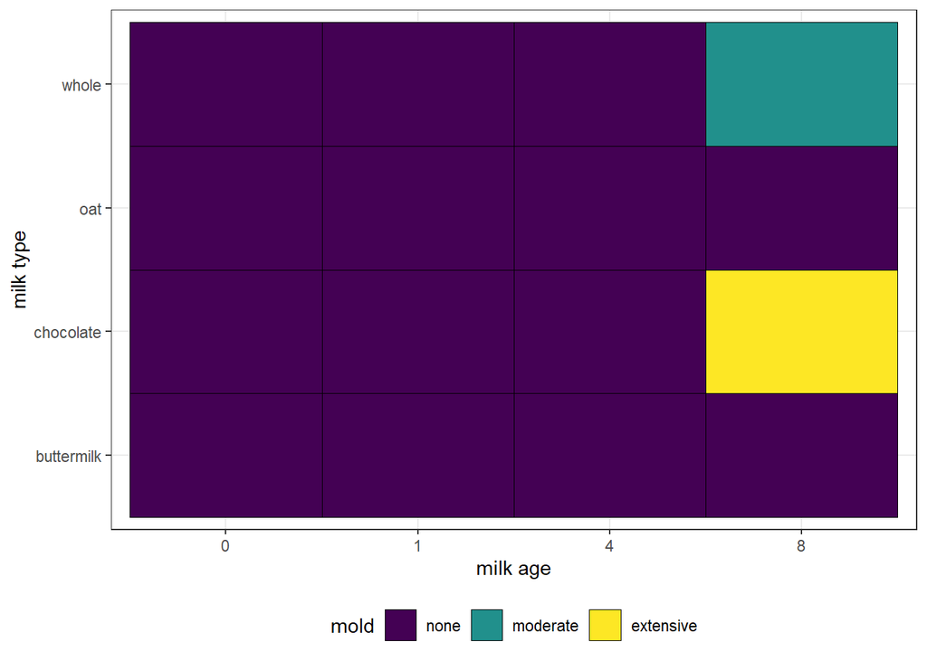

```r
# subset data
mold <- microbes |>
  select(milk_type, age, mold)

# create heatplot
ggplot(mold,
       aes(x = age, y = milk_type,
           fill = mold)) +
  geom_tile(color = "black") +
  scale_fill_viridis_d() +
  labs(x = "milk age", y = "milk type") +
  theme_bw() +
  theme(legend.position = "bottom")
```

To be able to see the change in the composition (relative abundance) of the different bacterial and yeast cell types, we should create individual plots for the milk types.

By creating a tidy data set with a column defining the cell type, we can then add a line to our code that will tell `R` to create individual panels for each milk type.

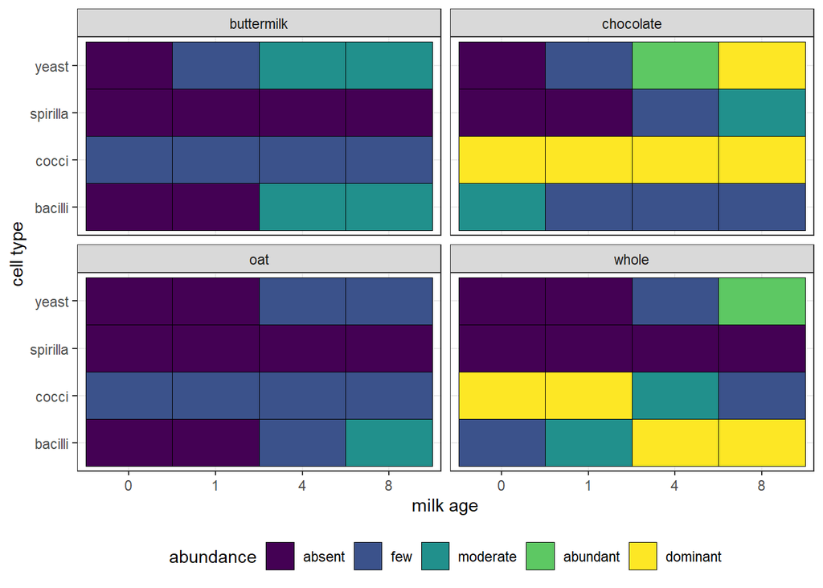

```r
# create a vector with milk types (modify accordingly)
milks <- c("whole", "buttermilk", "oat", "chocolate")

# create subset
cells <- microbes |>
  select(milk_type, age, cocci, bacilli, spirilla, yeast) |>
  pivot_longer(names_to = "cell_type", values_to = "abundance", 3:6) |>
  filter(milk_type %in% milks)

# plot multifaceted plot
ggplot(cells,
       aes(x = age, y = cell_type,
           fill = abundance)) +
  geom_tile(color = "black") +
  facet_wrap(. ~ milk_type) +
  scale_fill_viridis_d() +
  labs(x = "milk age", y = "cell type") +
  theme_bw() +
  theme(legend.position = "bottom")
```